# Lab 5 - Time-varying productivity of salmon

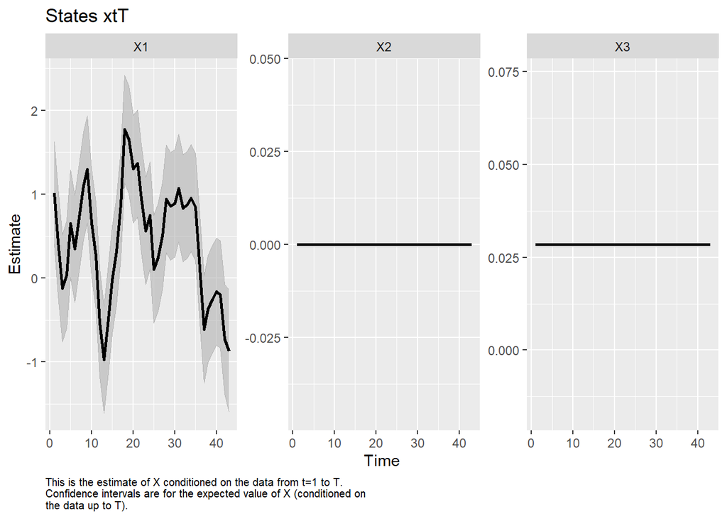

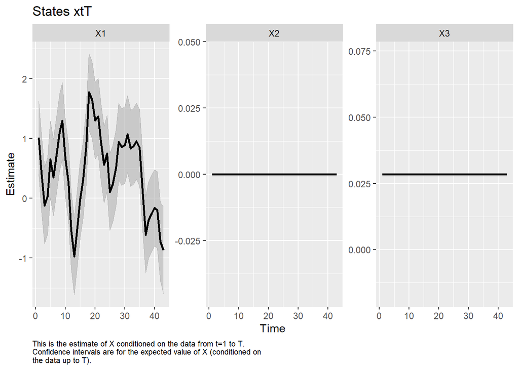

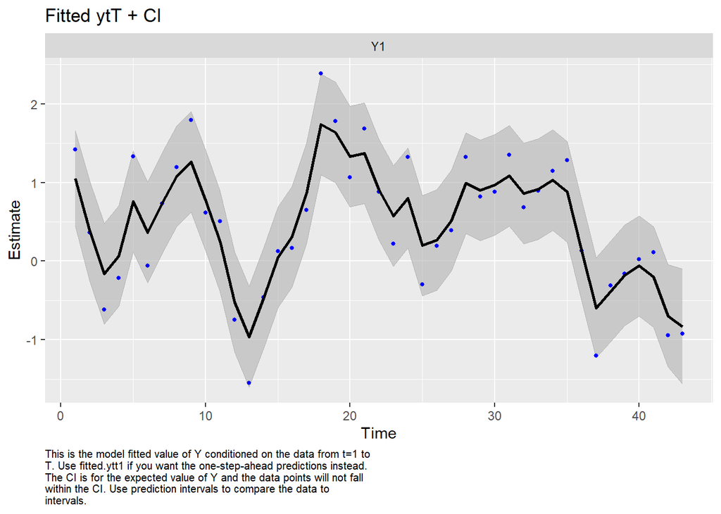

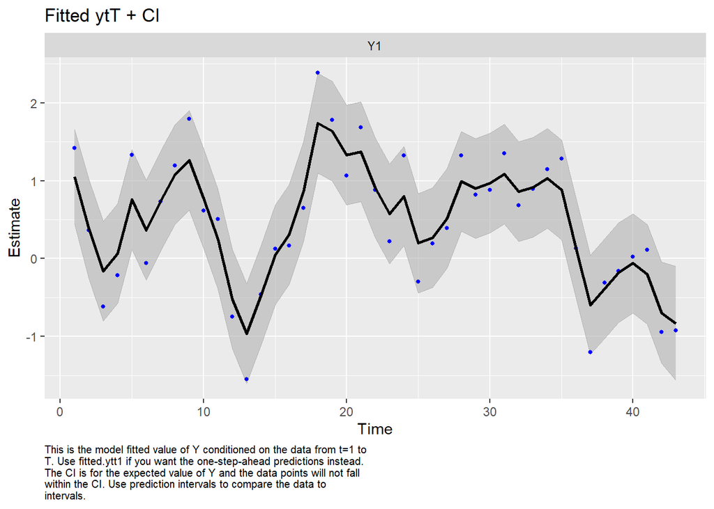

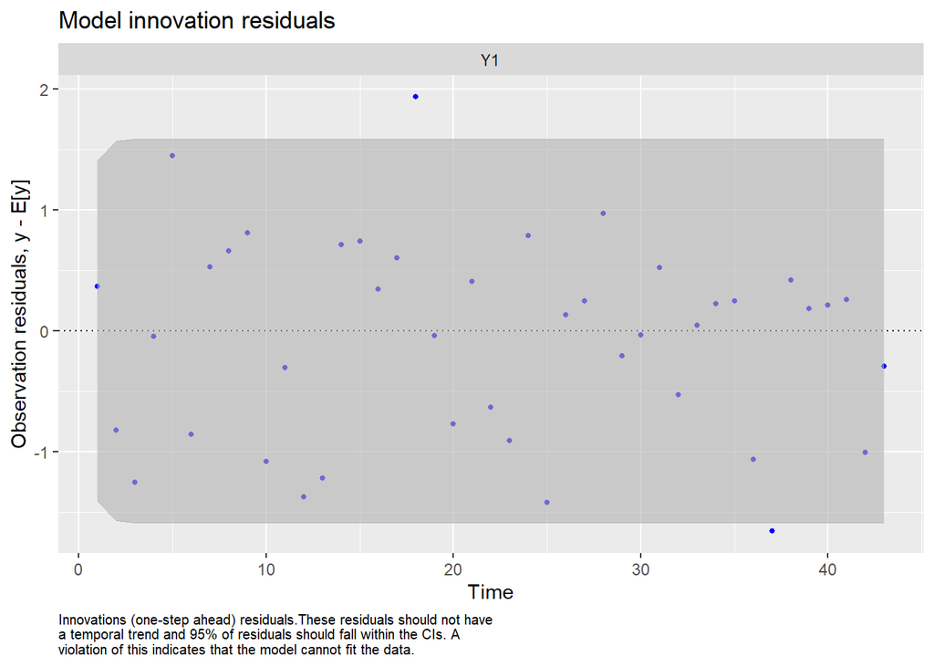

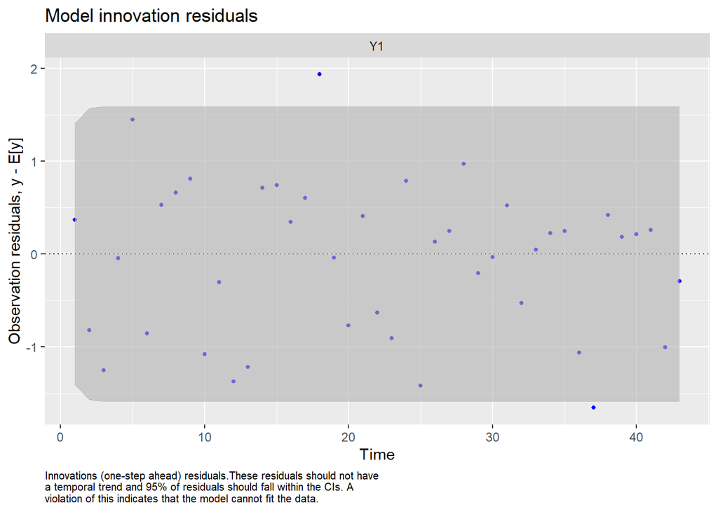

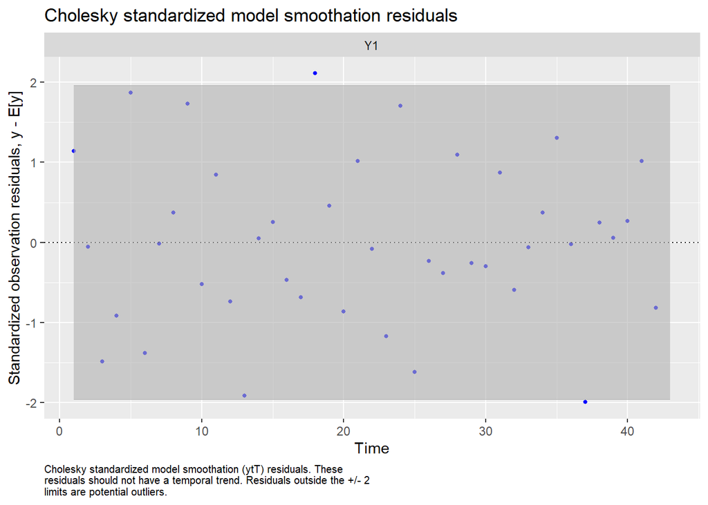

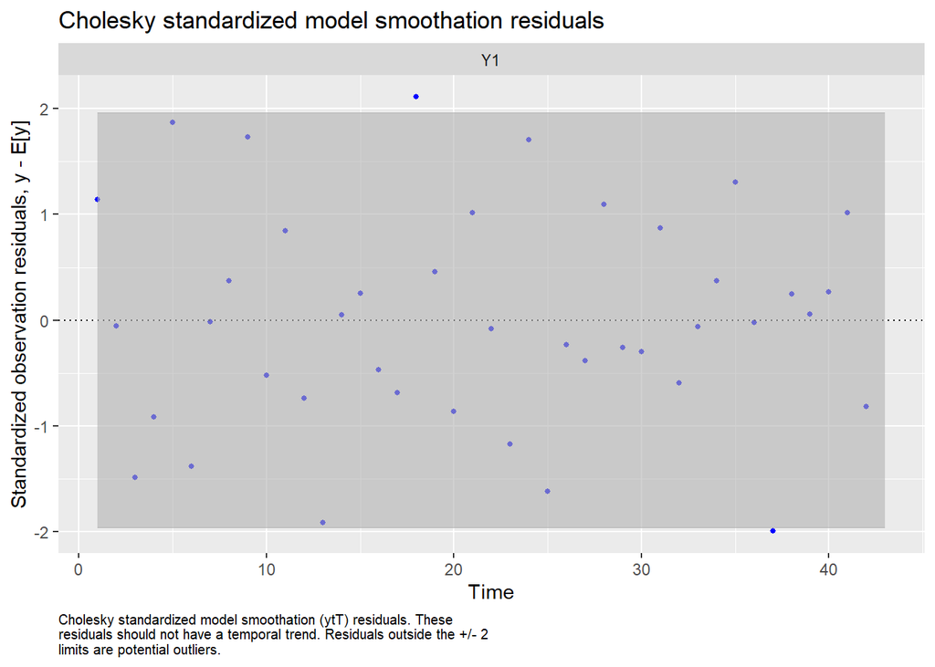

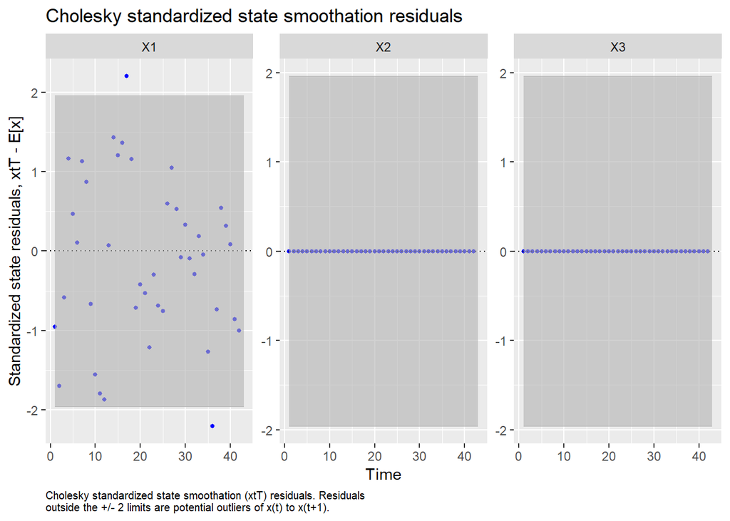

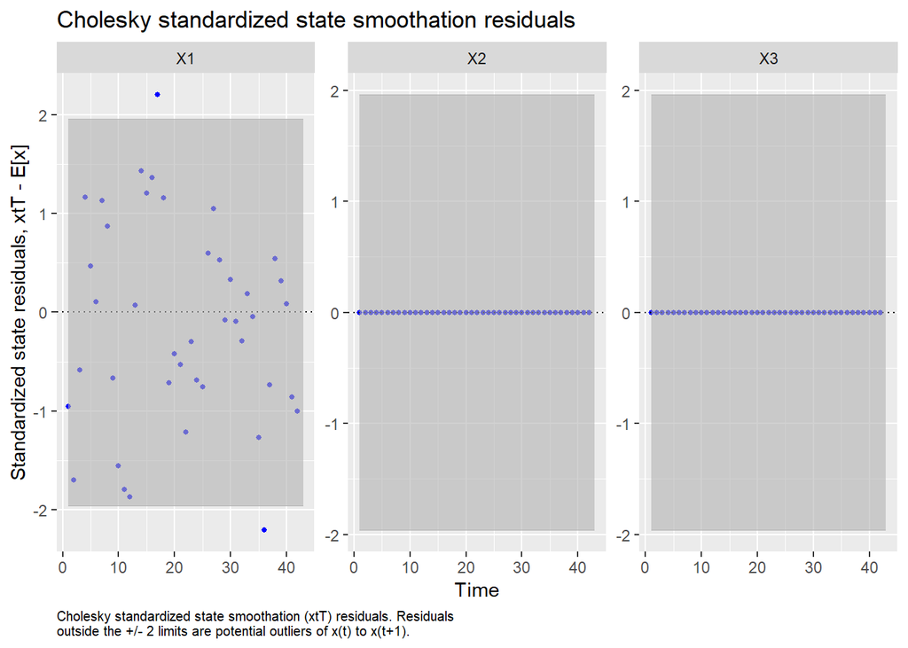

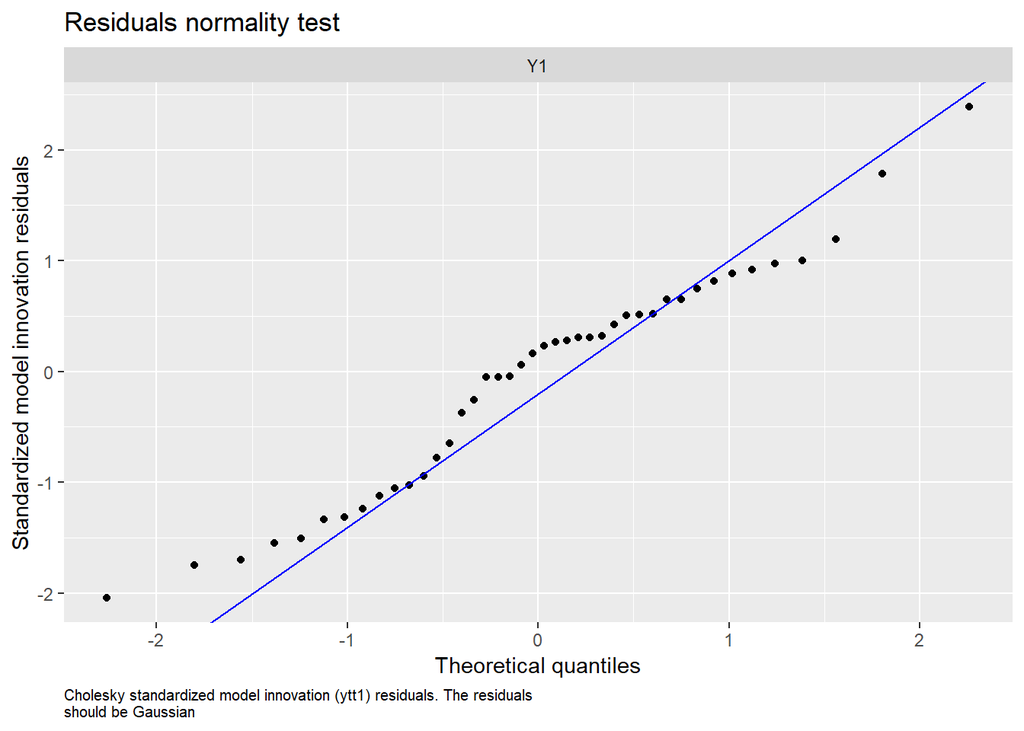

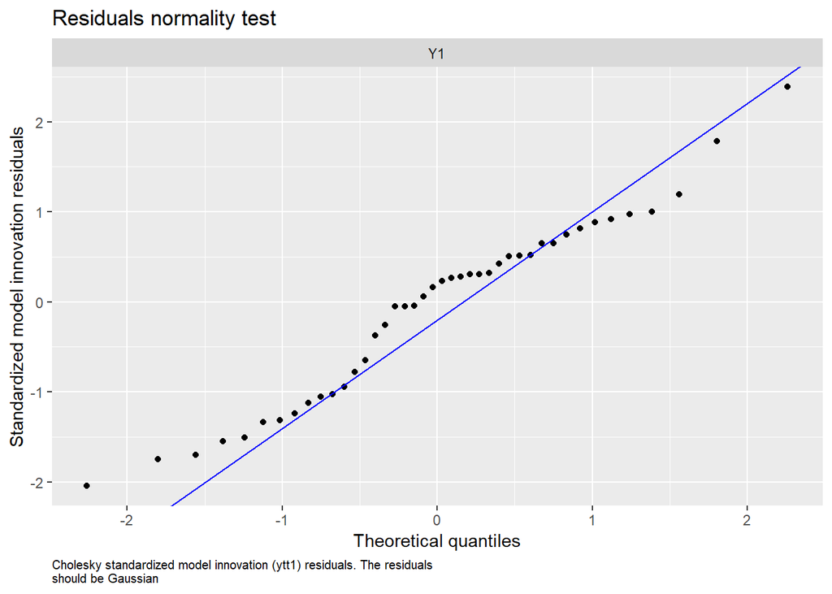

[4 more figures not shown]

```r
autoplot(summer_Rick, silent = TRUE)
```

## Full Ricker’s Model with Static Spawner Effect and Winter PDO covariate

4. Fit the expanded model that includes the winter PDO index as the covariate (`pdo_winter_t2`). What is the mean level of productivity? Plot the ts of $\delta_t$ and note the AICc for this model. Also plot appropriate model diagnostics.

$$\begin{align*}
\text{log}(R_t/S_t) = \alpha_t + \delta_t X_t - bS_t + v_t \\
\alpha_t = \alpha_{t-1} + w_t \\
\delta_t = \delta_{t-1} + w_t
\end{align*}$$

```r
#create the model params for the full Ricker's model
Z <- array(NA,c(1,3,TT)) # the array has 3 elements now
Z[1,1,] <- c(1)
Z[1,2,] <- SR_dat_short$spawners
Z[1,3,] <- SR_dat_short$pdo_winter_t2 # Covariate data is added to the Z matrix
# The model states are the covariate effects in a DLM

modlist <- list( # All other arguments are left as default
  Z = Z,
  U = "zero",
  A = "zero",
  B = "identity",
  Q = ldiag(list("q1",0,"q3")) # creates a custom Q matrix with zero variance for the spawner effect... I think? Additionally, the intercept variance may need to be contrained further
)

winter_Rick <- MARSS(Yt, model = modlist, control = list(maxit=3000), inits = list(x0 = matrix(c(1,0,0),3,1))) # added inits list due to marss error
```

```
## Success! abstol and log-log tests passed at 1358 iterations.
## Alert: conv.test.slope.tol is 0.5.
## Test with smaller values (<0.1) to ensure convergence.
##
## MARSS fit is
## Estimation method: kem
## Convergence test: conv.test.slope.tol = 0.5, abstol = 0.001
## Estimation converged in 1358 iterations.
## Log-likelihood: -51.38573
## AIC: 114.7715   AICc: 117.1048
##
##       Estimate
## R.R   1.96e-01
## Q.q1  3.11e-01
## Q.q3  0.00e+00
## x0.X1 1.13e+00
## x0.X2 1.32e-06
## x0.X3 1.54e-01
## Initial states (x0) defined at t=0
##
## Standard errors have not been calculated.
## Use MARSSparamCIs to compute CIs and bias estimates.
```

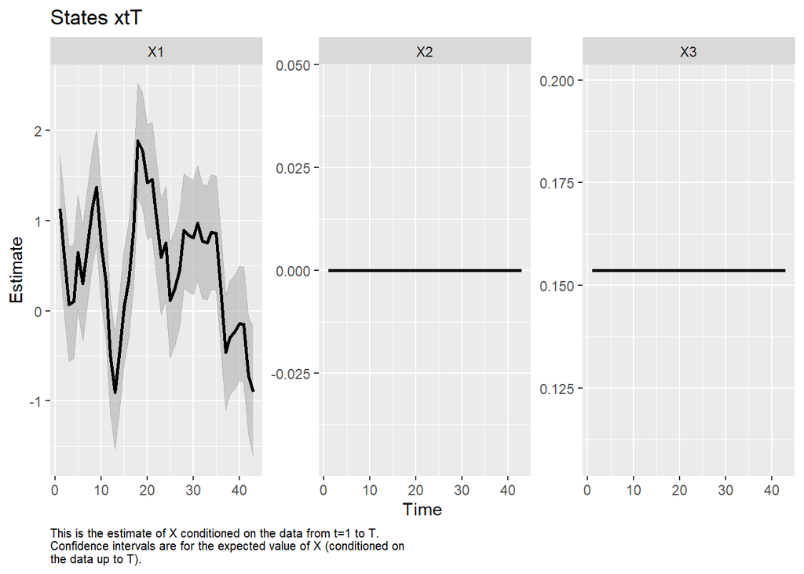

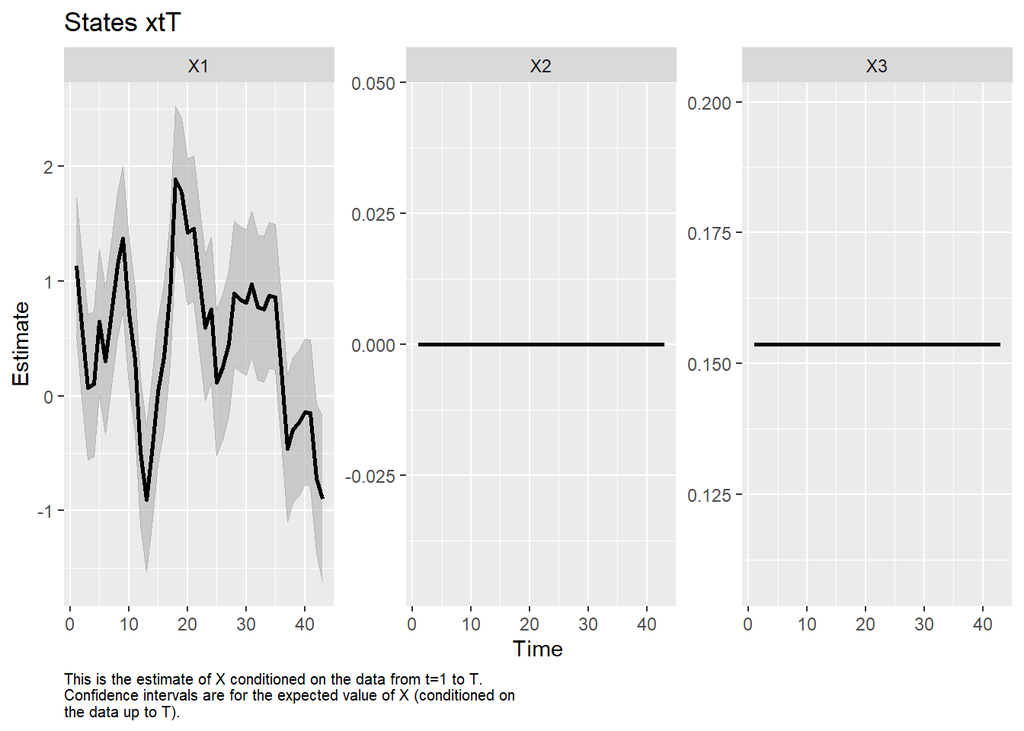

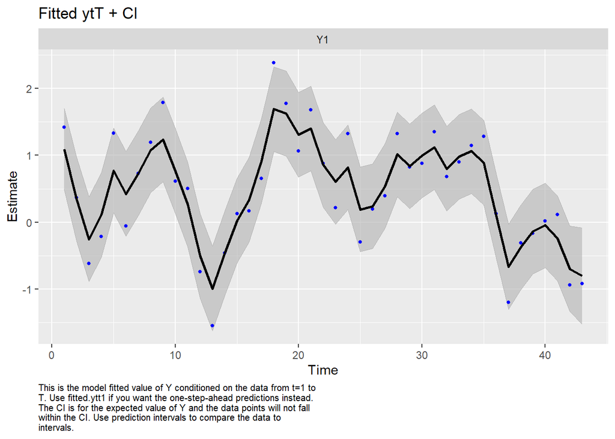

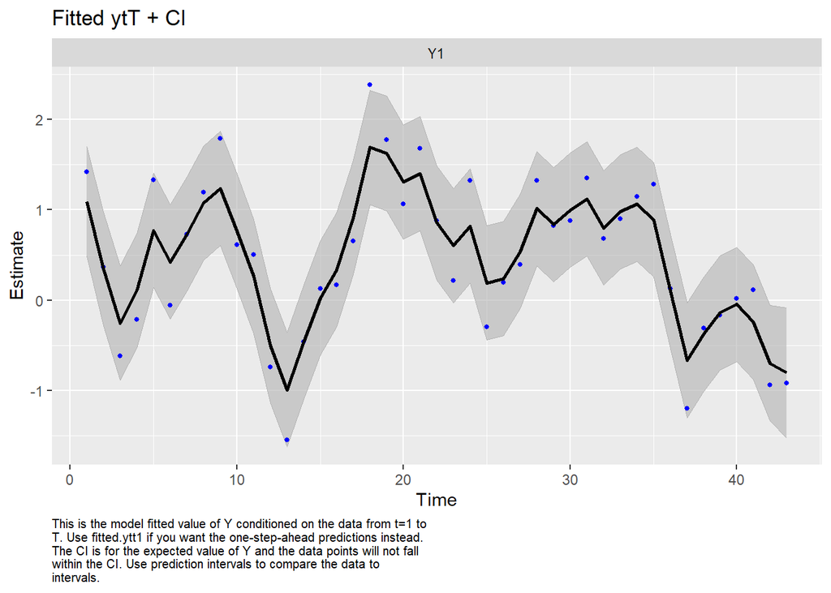

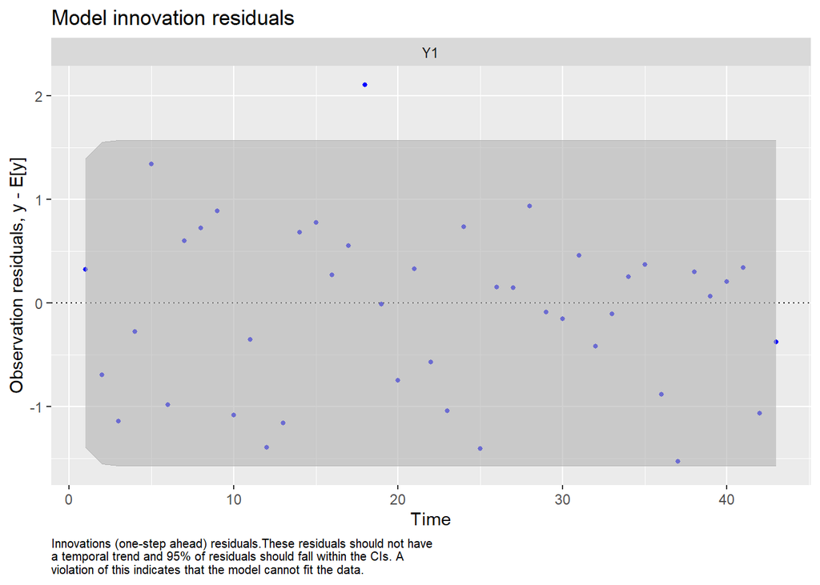

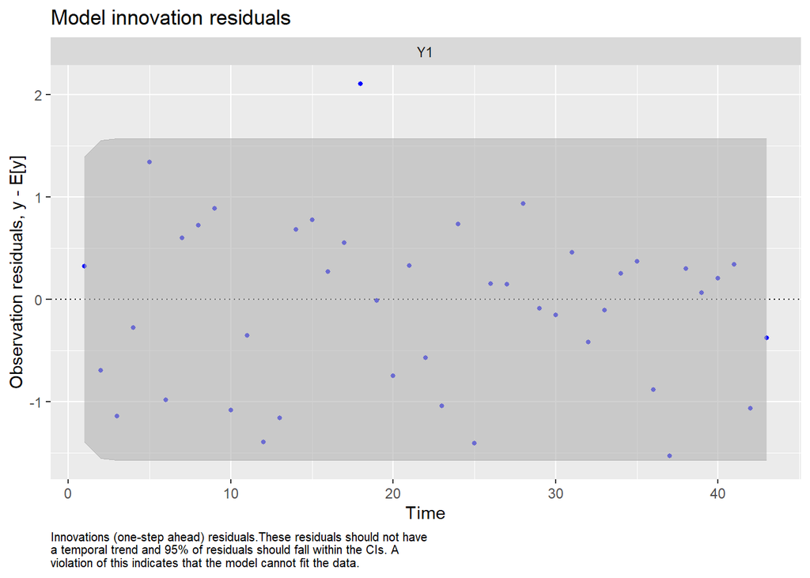

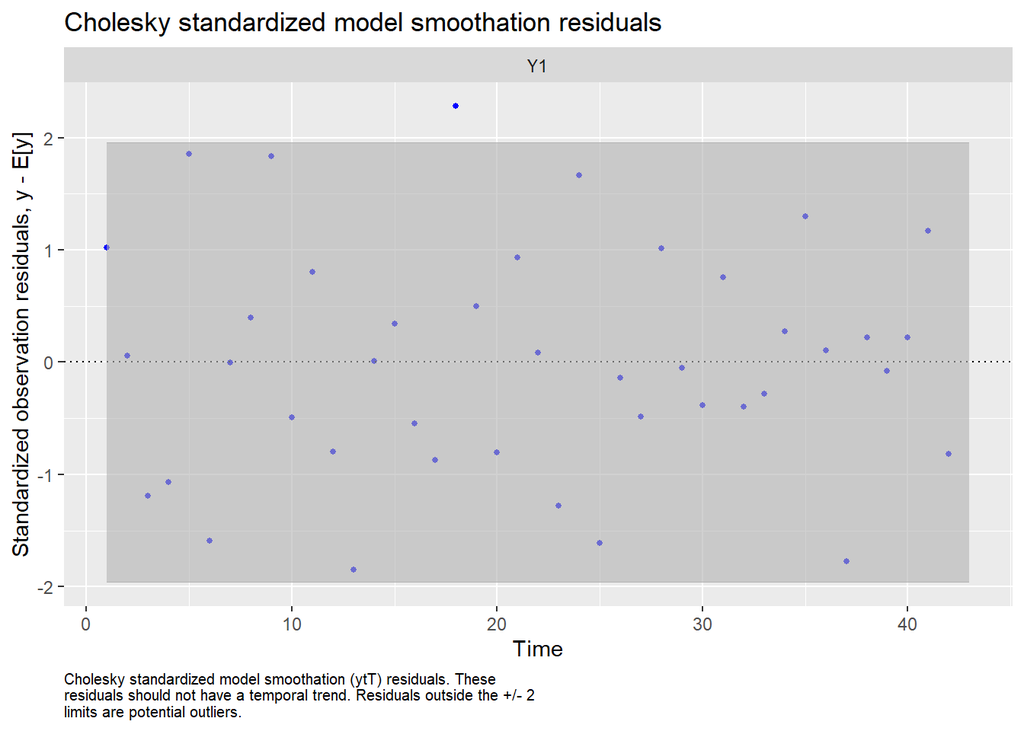

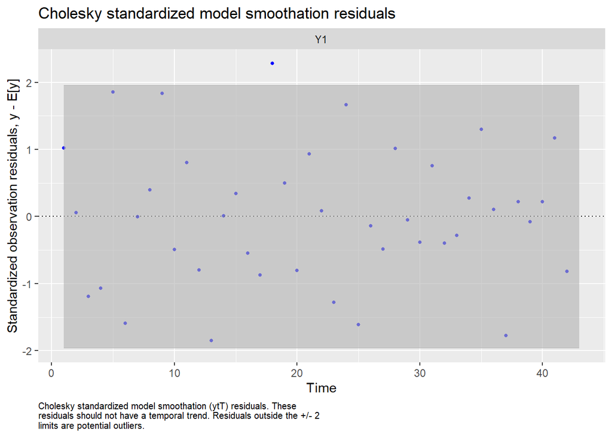

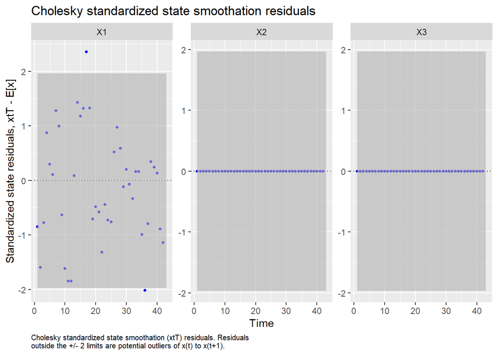

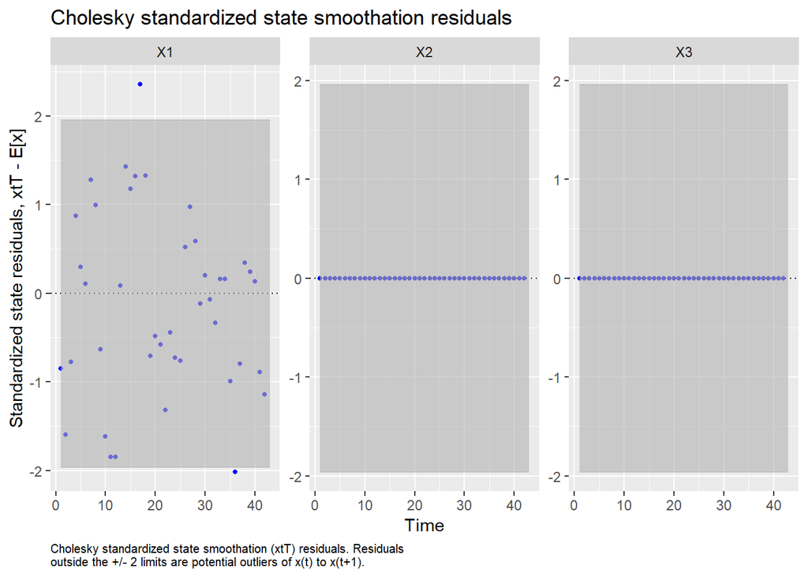

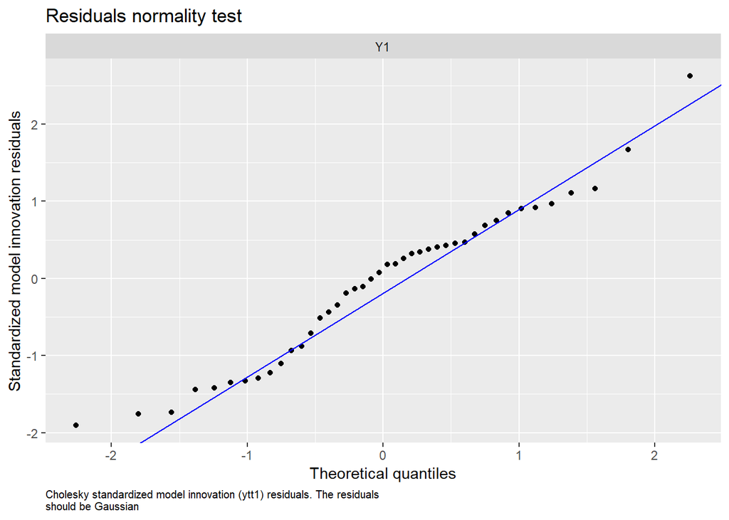

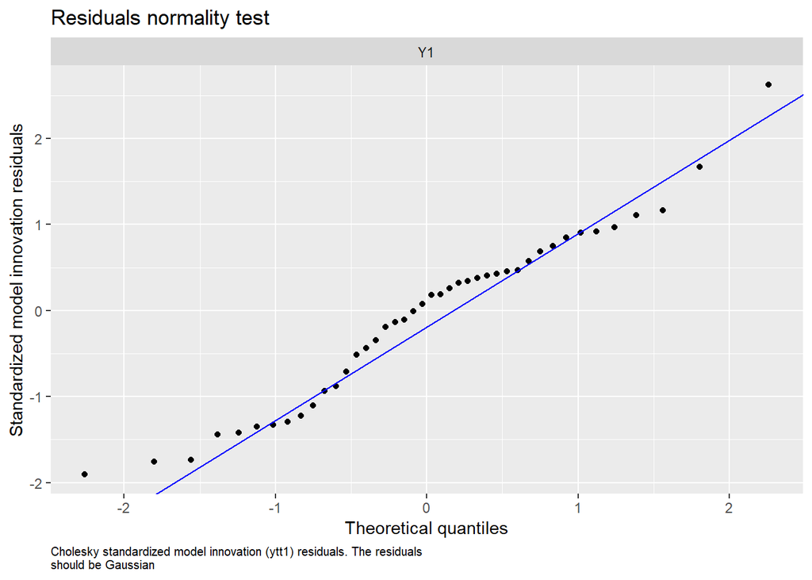

[4 more figures not shown]

```r
autoplot(winter_Rick, silent = TRUE)
```

Why is all the variation loaded onto the intercept again? Is this just a feature of the model? The winter effect is nonzero but still pretty small compared.

# Results

5. Based on AICc, which of the models above is the most parsimonious? Is it well behaved (i.e., are the model assumptions met)? Plot the model forecasts for the best model. Is this a good forecast model?

```r
#Summary Table

#Someone want to check I pulled the correct things for meanprod and SE?

mods <- c("Reduced Ricker","Full Ricker","Summer PDO","Winter PDO")
NLL <- c(reduced_Rick$logLik, full_Rick$logLik, summer_Rick$logLik, winter_Rick$logLik)
meanProd<-c(reduced_Rick$states[1,1] ,full_Rick$states[2,1],summer_Rick$states[3,1],winter_Rick$states[3,1])
SEs<-c(reduced_Rick$states.se[1,1] ,full_Rick$states.se[2,1],summer_Rick$states.se[3,1],winter_Rick$states.se[3,1])
tab <- cbind.data.frame(mods, NLL, meanProd, SEs)
kable(tab, col.names = c("Models", "Likelihood", "Means", "SE"))
```

| Models | Likelihood | Means | SE |
| --- | --- | --- | --- |
| Reduced Ricker | -51.87179 | 1.0037722 | 0.312086 |
| Full Ricker | -51.80921 | 0.0000070 | 0.000000 |
| Summer PDO | -51.78324 | 0.0284538 | 0.000000 |
| Winter PDO | -51.38573 | 0.1536993 | 0.000000 |

```r
#AICc Table

mods <- c("Reduced Ricker","TimeVar Intercept","Summer PDO","Winter PDO")
aic <- c(reduced_Rick$AICc, full_Rick$AICc, summer_Rick$AICc, winter_Rick$AICc)
daic <- aic-min(aic)
tab <- cbind.data.frame(mods, aic, daic)
kable(tab, col.names = c("Models", "AICc", "delta AICc"))
```

| Models | AICc | delta AICc |
| --- | --- | --- |
| Reduced Ricker | 110.3590 | 0.000000 |
| TimeVar Intercept | 112.6711 | 2.312095 |
| Summer PDO | 117.8998 | 7.540854 |
| Winter PDO | 117.1048 | 6.745832 |

According to AICc, the most parsimonious model was the Reduced Ricker, which was essentially a random walk model. While adding complexity with the other models did decrease the negative log likelihoods, the improved fits to data were quite small, and adding parameters didn’t improve fit enough to justify using more complex models.

## Forecast data

We used the best fitting model to do the forecast, which was the Reduced Ricker.

Forecasting from a DLM involves two steps:

1. Get an estimate of the regression parameters at time $t$ from data up to time $t-1$. These are also called the one-step ahead forecast (or prediction) of the regression parameters.
2. Make a prediction of $y$ at time $t$ based on the predictor variables at time $t$ and the estimate of the regression parameters at time $t$ (step 1). This is also called the one-step ahead forecast (or prediction) of the observation.

```r
## shrink the window of years so the response variable will have a full set of values
SR_dat_short2 <- SR_data[SR_data[,"brood_year"] >= 1956 & SR_data[,"brood_year"] <= 2005, ]

#Create a column for the response variable
SR_dat_short2$Yt <- log(SR_dat_short2$recruits/SR_dat_short2$spawners) #Yt represents log of recruits over spawners.

#Create the observation matrix
Yt <- t(SR_dat_short2$Yt)

#determines number of elements
TT <- nrow(SR_dat_short2)


# our top model from above: Reduced Ricker

#create the model params
Z <- array(NA,c(1,1,TT))
Z[1,1,] <- c(1)

modlist <- list( # All other arguaments are left as default
  Z = Z,
  U = "zero",
  A = "zero",
  B = "identity"
)

#Run again for good measure
reduced_Rick <- MARSS(Yt, model = modlist)
```

```
## Success! abstol and log-log tests passed at 26 iterations.
## Alert: conv.test.slope.tol is 0.5.
## Test with smaller values (<0.1) to ensure convergence.
##
## MARSS fit is
## Estimation method: kem
## Convergence test: conv.test.slope.tol = 0.5, abstol = 0.001
## Estimation converged in 26 iterations.
## Log-likelihood: -51.87353
## AIC: 109.7471   AICc: 110.3625
##
##       Estimate
## R.R      0.213
## Q.Q      0.301
## x0.x0    0.998
## Initial states (x0) defined at t=0
##
## Standard errors have not been calculated.
## Use MARSSparamCIs to compute CIs and bias estimates.
```

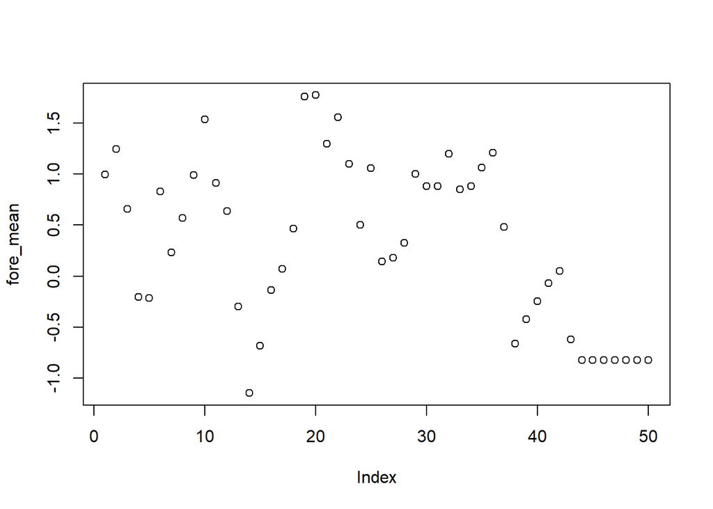

```r
## get list of Kalman filter output
kf_out <- MARSSkfss(reduced_Rick)

## forecasts of regr parameters; 2xT matrix
eta <- kf_out$xtt1

## ts of E(forecasts)
fore_mean <- vector()
for (t in 1:TT) {
    fore_mean[t] <- Z[, , t] %*% eta[, t, drop = FALSE]
}

plot(fore_mean)
```

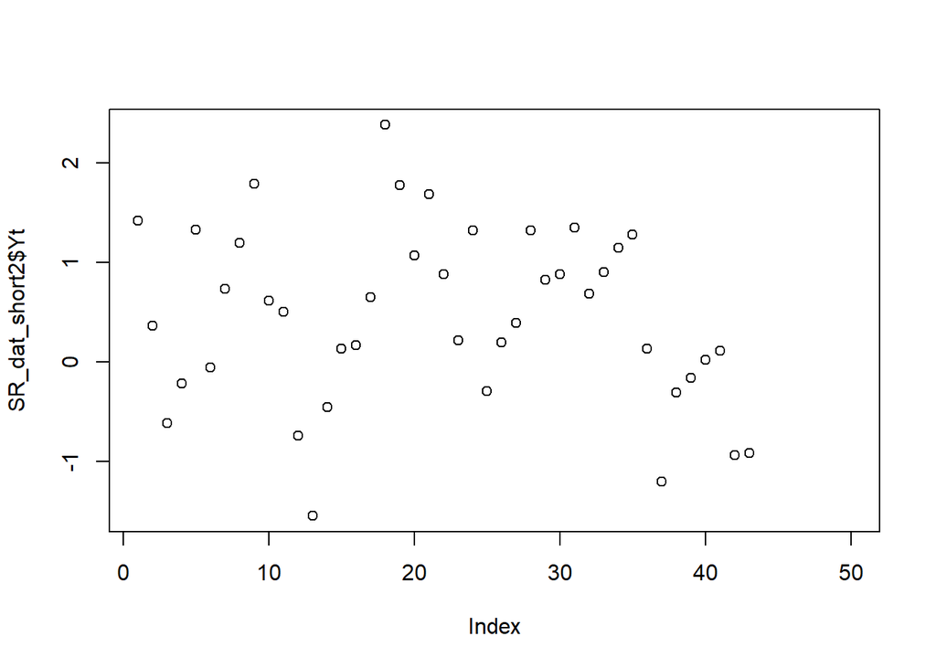

```r
plot(SR_dat_short2$Yt)
```

[figure not shown]

```r
plot(x=SR_dat_short2$brood_year , y= fore_mean, type = "b", pch = 19,
     col = "red", xlab = "Year", ylab = "log(R/S)", ylim = c(-2, 3), xlim = c(1956, 1998))
lines(SR_dat_short2$brood_year, SR_dat_short2$Yt, pch = 18, col = "blue", type = "b", lty = 2)
legend("topright", legend=c("data", "forecast"),
       col=c("red", "blue"), lty = 1:2, cex=0.8)
```

The one step ahead forcast follows the trend of the data, but is lagged behind the data by one year. ##

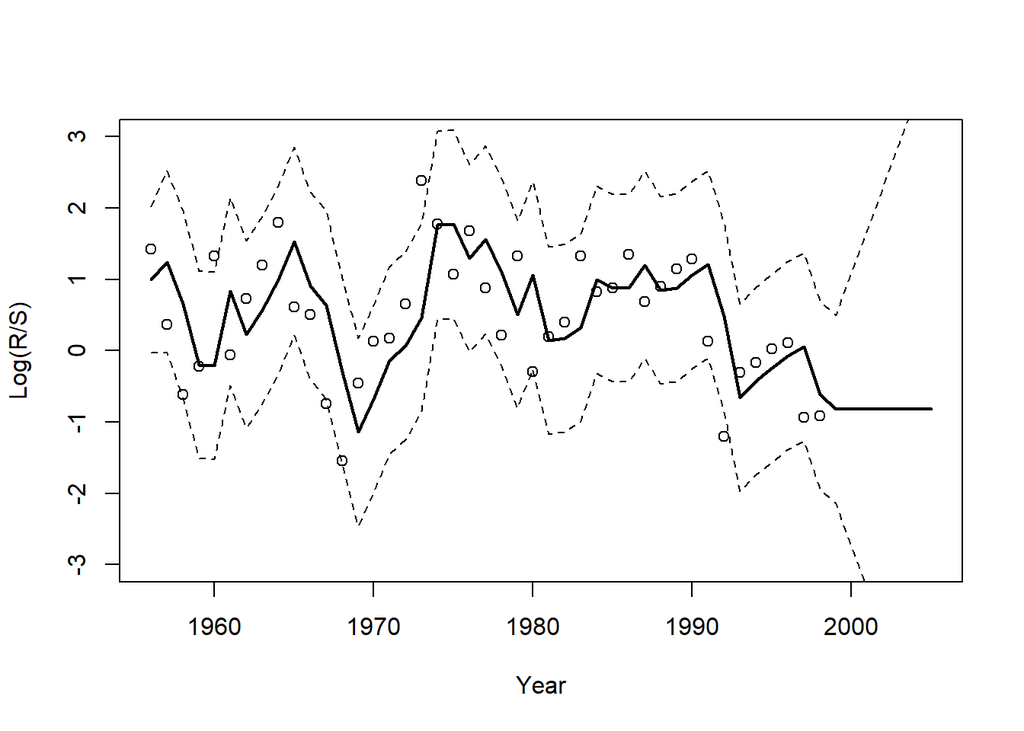

```r
# compute the forecast variance:

## variance of regr parameters; 1x2xT array
Phi <- kf_out$Vtt1

## obs variance; 1x1 matrix
R_est <- coef(reduced_Rick, type = "matrix")$R


## ts of Var(forecasts)
fore_var <- vector()
m<-1 #number of regression pars
for (t in 1:TT) {
    tZ <- matrix(Z[, , t], m, 1)  ## transpose of Z
    fore_var[t] <- Z[, ,t] %*% Phi[, , t] %*% tZ + R_est
}



plot(x = SR_dat_short2$brood_year, y=fore_mean, type = "l", lwd = 2, xlab = "Year", ylab = "Log(R/S)", ylim = c(-3,3))
lines(x = SR_dat_short2$brood_year, y = fore_mean-2*fore_var, lty = 2)
lines(x = SR_dat_short2$brood_year, y = fore_mean + 2*fore_var, lty=2)
points(x =SR_dat_short2$brood_year, y = SR_dat_short2$Yt)
```

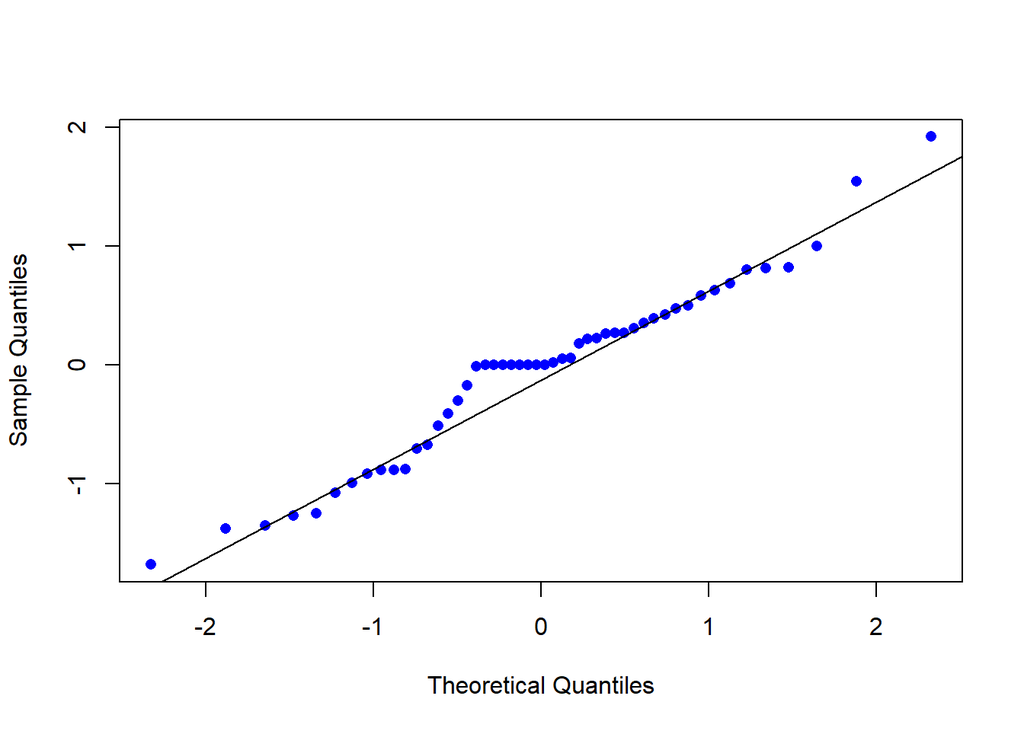

```r
## forecast errors
innov <- kf_out$Innov

## Q-Q plot of innovations
qqnorm(t(innov), main = "", pch = 16, col = "blue")
## add y=x line for easier interpretation
qqline(t(innov))
```

There are some odd trends in this QQ plot and to be honest, I’m not sure the best way to interpret it.

6. Consider other environmental factors that could influence the time-varying intrinsic productivity of these salmon. For example, are there other large-scale indices of ocean conditions (e.g., sea-surface temperature, El Niño Southern Oscillation)? You could also consider the possible influence of other salmon stocks such as those we examined in Lab 1.

The Kvichak River system flows into Bristol Bay Alaska, and some other possible environmental factors that could influence time-varying productivity could include sea ice dynamics, driving the underlying primary productivity and food availability of plankton for salmon that have migrated to the Bering Sea, which could have an impact on fecundity and survival. Sea ice extent is correlated with certain species of copepods, with varying lipid content, and some species may be better food for salmon. Sea Ice would likely be correlated with sea surface temperatures, but SST could be another covariate to explore as the Bering Sea has shown evidence of warming in recent decades.

# Discussion

Ultimately this lab was a good lesson in covariates not improving model fits enough to justify more complex models. While we can speculate and make inference on environmental impacts on factors, such as cycles such as PDO on spawner recruit relationships, sometimes the most simple models explain enough of the relationship where additional complexity isn’t necessary. In this lab, the model with the lowest AICc was essentially a random walk process, and while considering density dependency and environmental processes such as summer and winter PDO did ever so slightly improve the negative log likelihoods, the fit gained from the additional parameters wasn’t worth it.

# Team contributions

Eric completed the data cleaning and set up the primary four models. Madi added plots and created the NLL and AICc tables and both Karl and Madi tackled the forecast portion of the lab. Discussion and notes in the document were added by Madi and Eric and Karl proofread and edited where appropriate.